# Final Project

Eric Peterson

2023-03-29

## Aims

Identify demographic qualities of census tracts associated with higher rates of converting live birth statistics five years ago to current kindergarten enrollments.

## Background

School districts face uncertainty planning for their kindergarten enrollment. In the School District of Philadelphia (SDP) and other school systems starved of resources, planning is important to allocate limited budgets. Where localized birth datasets can be available to decisionmakers, analysts notice variable conversion of those births to kindergarten enrollments five years later. Competition for resources can motivate stakeholders invested in retaining resources at individual schools to make optimistic assumptions about kindergarten enrollment. An impartial, rigorous approach can identify variables correlated to greater participation in kindergarten enrollment and drive equitable allocation of resources.

## Hypotheses

I expect that families in catchments with higher socioeconomic status will opt out of SDP public schools. Catchments with higher percentage white population will have worse conversion. Catchments with greater variance in household income will have worse conversion.

## Methods

Data will be a few years old, specific years available through internet archives.

Catchment boundaries each year are available through SDP. Enrollment data is available through SDP.

I’ll use PostGIS to aggregate catchment-level summaries of census tract data through the ACS and the live births data. This will focus on summarizing the live births data, white percent population, and household income.

I’ll use the available SDP enrollment data to find the number of students from each catchment enrolled in SDP kindergarten. (area weighted interpolation) I’ll use that enrollment to compute the conversion rate.

I’ll be comparing this conversion rate of the catchment to the household income and proportions of population by race.

Each of the catchments is effectively one sample. I’ll run our statistical analysis on the set of samples for each year.

## Pipeline

A summary so far:

1. python script
- Download births files from internet archive -> Manually clean files -> Load each file to a table in PostGIS
- Download enrollment data from SDP DPO -> Parse out the data from the files (in three formats) -> Load each file to a table in PostGIS
- Load 2010 census tract shape files
  - ogr2ogr subprocess call
- Load 2010 census block group shape files
  - ogr2ogr subprocess call
- Load 2010 census data: race, TODO others
  - api call
- Download catchment shape files from SDP DPO -> Unzip each file -> ogr2ogr subprocess call to load just the elementary school catchments
2. sql script
- Union all catchment years together
- Find intersections of catchments and census tracts. Compute the ratio of each tract in each catchment.
- Find intersections of catchments and census block groups. Compute the ratio of each block group in each catchment.
- Union all birth years together
- Compute births by catchment
  - Join births to the intersection of tracts and catchments.
  - Multiply the births in catchment by the ratio of area in each tract.
  - Sum the area-weighted births by catchment as our count of births by catchment.
- Union all enrollment years together
- Join enrollments to the count of births by catchment. Compute the ratio of births to enrollments.
- Compute demographic information about catchments
  - Join demographics to the intersection of block groups and catchments.
  - Multiply the raw counts of each demographic by the ratio of area in each block group.
  - Sum the area-weighted raw counts by catchment.
  - Compute the proportion of each demographic for each catchment.

## Exploration

```
## [1] "Connecting to Database…"
## [1] "Database Connected!"
```

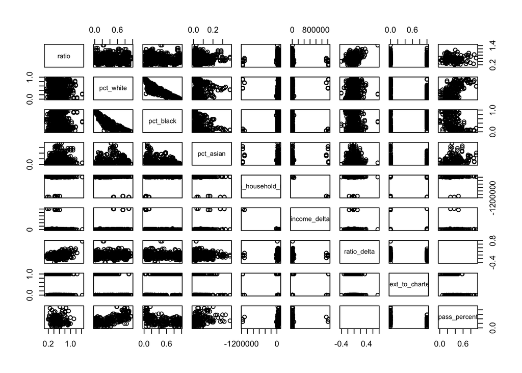

Births and enrollment are correlated

But there’s serious hetroscedasticity between births and enrollment.

There’s no clear correlation between the year to year changes, unfortunately.

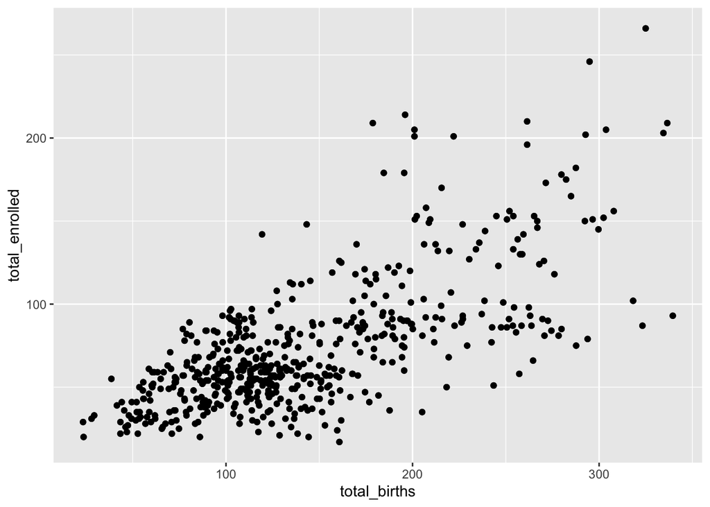

```r
ggplot(df_full_compare, aes(x=total_births, y=total_enrolled)) +
  geom_point()
```

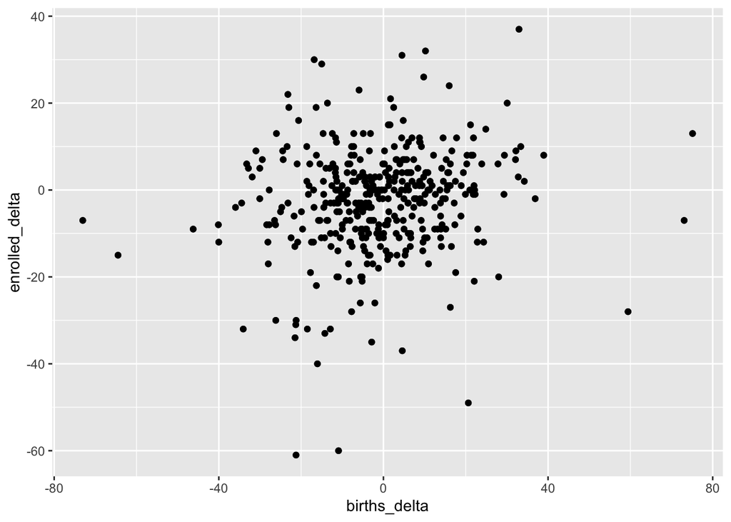

```r
# TODO confirm the significance of this correlation, explore the strength


ggplot(df_full_compare, aes(x=births_delta, y=enrolled_delta)) +
  geom_point()
```

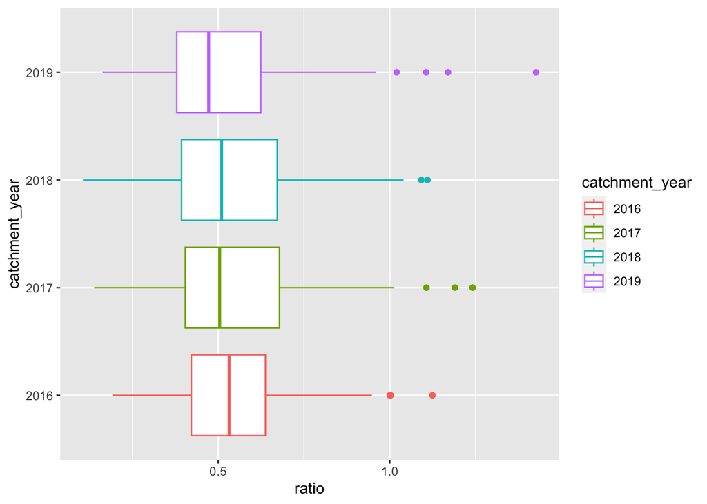

```r
ggplot(df_full_compare, aes(x=catchment_year, y=ratio, group=catchment_year, color=catchment_year)) +
  coord_flip() +
  geom_boxplot()
```

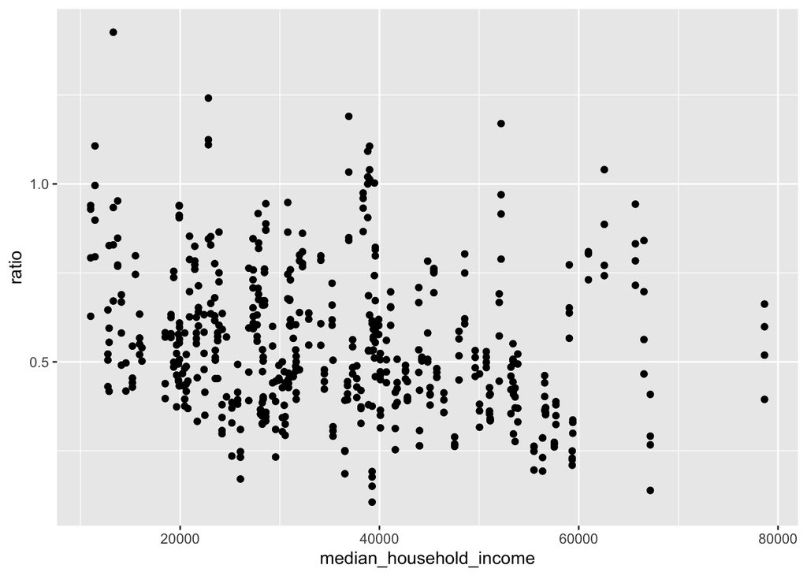

```r
# remove outliers that ruin our income data
df.income <- df_full_compare[c(1,2,3,7)]
df.income$median_household_income[df.income$median_household_income < -20000] <- NA
df.income <- subset(df.income, complete.cases(df.income))

ggplot(df.income, aes(x=median_household_income, y=ratio)) +
  geom_point()
```

### Takeaways

- There’s skew in the distribution of ratios
- There’s no apparent correlation between race and ratio
- There might be slight correlation in the relationship between income and ratio.
- There seems to be clustering around zero change in ratio deltas and income deltas.

Being in a catchment next to a charter school catchment doesn’t affect your ratio too much.

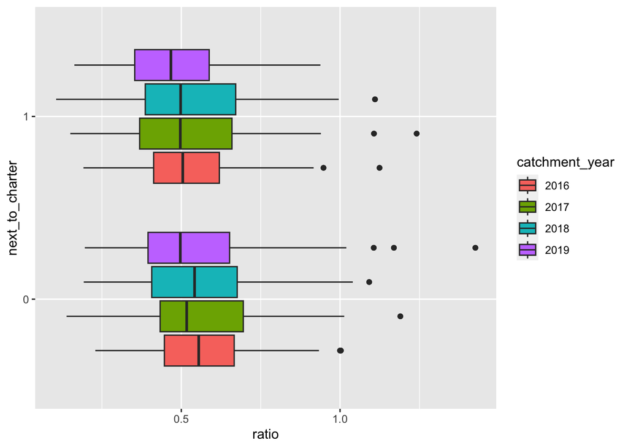

```r
df.charter <- df_full_compare

df.charter$next_to_charter <- as.factor(df.charter$next_to_charter)

ggplot(df.charter, aes(x=next_to_charter, y=ratio, fill=catchment_year)) +
  coord_flip() +
  geom_boxplot()
```

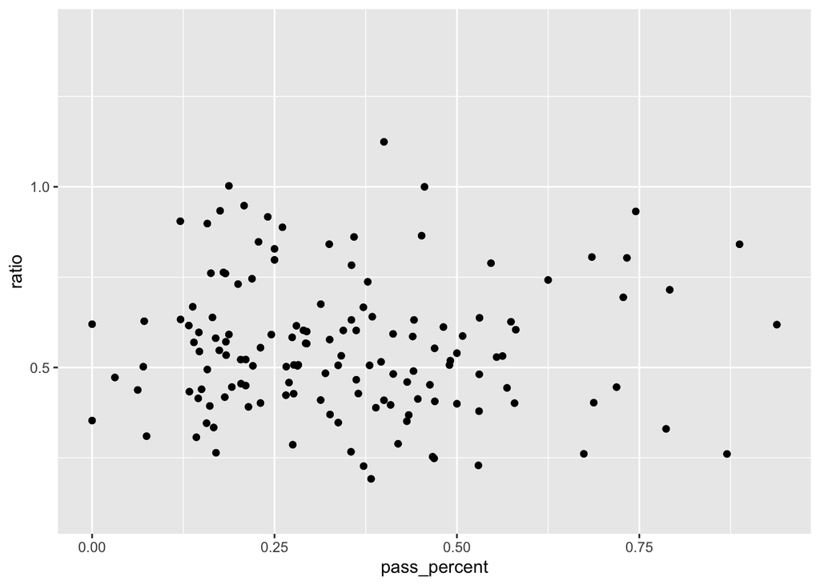

[figure not shown]

```r
ggplot(df_full_compare, aes(x=pass_percent, y=ratio)) +
  geom_point()
```

```r
dbDisconnect(connec)
```

```
## [1] TRUE
```